```python
!jupyter nbconvert --execute --to html "/content/drive/MyDrive/Colab Notebooks/Applied ML/PAC_submission_x.ipynb"
```

# Written Report

**Keeping it simple**

For most of this competition, I focused on one core approach: linear regression using Ordinary Least Squares (OLS). I chose it because linear regression is one of the easiest models to interpret and explain to stakeholders. The more complex a model becomes, the harder it is to translate those insights into business decisions. Early on, I also learned that not every variable deserves a place in the model. Through feature selection, I discovered that several predictors added more noise than value, and removing them helped create a cleaner story around monthly_spend.

**Model 5**

However, when I included more predictors in Model 5, the model began to take shape. The RMSE dropped, the R² improved, and the combined predictors gave me a more convincing narrative about what influences spending. While not every coefficient appeared meaningful, the model produced stronger performance and a clearer view of the relationships in the dataset.

**Statistical Significance** The OLS summary report became one of my most valuable tools. The p-values helped me understand which variables had a meaningful relationship with monthly spending. I used a threshold of 0.05 to guide my decisions. If a predictor fell below that threshold, it signaled that it was statistically significant and likely worth including in future versions of the model. This step pushed me to think more critically about what belonged in the model rather than letting the algorithm decide for me.

**Missteps along the way**

Looking back, I can clearly see one missed opportunity: I should have spent more time exploring and transforming the data before modeling. A more thorough Exploratory Data Analysis (EDA) would have helped me uncover patterns, identify outliers, and think about what transformations or feature engineering might reduce the RMSE.

If I had created more visualizations—bar charts, histograms, scatter plots, and relationship charts—I could have seen interactions between variables more clearly. I also could have built helper functions to normalize features, create ratios, and generate binary flags. These kinds of engineered features might have strengthened the model and improved prediction accuracy.

**Learning outcomes** This competition taught me that strong analysis does not begin with modeling—it begins with understanding the data. Much of data work is repetitive, but what separates a strong analyst is the ability to reshape data into something more meaningful. Tools like feature selection helped me identify which predictors mattered most, but I also learned that domain knowledge can make those outcomes even more insightful.

I also learned that outliers matter. Some models can overfit or distort predictions when extreme values are present, and while I wondered whether polynomial features might smooth that issue, it ultimately did not provide a better fit.

Overall, this challenge blended theory and experimentation. Reducing the RMSE wasn’t just about applying models—it was about exploring, questioning assumptions, and sometimes testing ideas even when they might not work. That mindset is at the core of being a good analyst, engineer, or developer: curiosity, patience, and a willingness to think differently.

# Submission 1

```python
from google.colab import drive
drive.mount('/content/drive')
```

```python
#Reading in analysis data to start a linear regression model. This is Model1

import pandas as pd
a_data = pd.read_csv('/content/drive/MyDrive/Colab Notebooks/Applied ML/analysis_data.csv')
X = a_data.loc[:,['credit_score', 'travel_frequency']]
y = a_data.monthly_spend
from sklearn.linear_model import LinearRegression
reg = LinearRegression()
reg.fit(X,y)
pred = reg.predict(X)
```

```python
#Reading in the scoring data to apply model to generate predictions

scoring_data = pd.read_csv('/content/drive/MyDrive/Colab Notebooks/Applied ML/scoring_data.csv')
scoring_data_X = scoring_data.loc[:,['credit_score', 'travel_frequency']]
pred = reg.predict(scoring_data_X)
```

```python
submission_file = pd.DataFrame({'customer_id': scoring_data.customer_id, 'monthly_spend': pred})
submission_file.to_csv('submission_file_1.csv',index = False)
```

```python
#Reviewing Model1 summary

# To get model summary-like information, you can calculate metrics like R-squared and coefficients
from sklearn.metrics import r2_score, mean_squared_error, root_mean_squared_error
import numpy as np

#Calculate RMSE
rmse = np.sqrt(np.mean(np.square(reg.predict(X) - y)))
print(f"Rmse: {rmse}")

# Calculate R-squared
r2 = r2_score(y, reg.predict(X))
print(f"R-squared: {r2}")

# Print the coefficients
print(f"Coefficients: {reg.coef_}")

# Print the intercept
print(f"Intercept: {reg.intercept_}")
```

```
Rmse: 457.3909203668296
R-squared: 0.2753205366538085
Coefficients: [  1.58224662 119.89052514]
Intercept: 214.6542567065087
```

# Submission 2

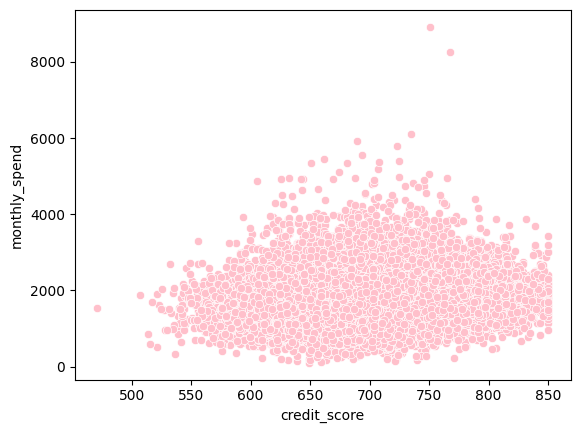

```python
#Creating a visual for the intended outcome with 1 predictor from model1 to gauge overview
#high variance with monthly spend
import numpy as np
import matplotlib.pyplot as plt
import seaborn as sns

sns.scatterplot(data = a_data , x = 'credit_score', y = 'monthly_spend', color = 'pink')
plt.show()
```

```python
# Now adding model2. Trying OLS for a different regression model
from statsmodels.formula.api import ols
reg = ols('monthly_spend ~ credit_score + travel_frequency', data = a_data)
model2 = reg.fit()

model2.params
```

|  | 0 |
| --- | --- |
| Intercept | 214.654257 |
| credit_score | 1.582247 |
| travel_frequency | 119.890525 |

**dtype:** float64

```python
# Summarzing Model2
model2.summary()
```

OLS Regression Results

| Dep. Variable: | monthly_spend | R-squared: | 0.275 |
| --- | --- | --- | --- |
| Model: | OLS | Adj. R-squared: | 0.275 |
| Method: | Least Squares | F-statistic: | 7598. |
| Date: | Mon, 20 Oct 2025 | Prob (F-statistic): | 0.00 |
| Time: | 22:43:23 | Log-Likelihood: | -3.0178e+05 |
| No. Observations: | 40000 | AIC: | 6.036e+05 |
| Df Residuals: | 39997 | BIC: | 6.036e+05 |
| Df Model: | 2 |  |  |
| Covariance Type: | nonrobust |  |  |

|  | coef | std err | t | P>\|t\| | [0.025 | 0.975] |
| --- | --- | --- | --- | --- | --- | --- |
| Intercept | 214.6543 | 32.083 | 6.691 | 0.000 | 151.772 | 277.537 |
| credit_score | 1.5822 | 0.046 | 34.762 | 0.000 | 1.493 | 1.671 |
| travel_frequency | 119.8905 | 1.012 | 118.417 | 0.000 | 117.906 | 121.875 |

| Omnibus: | 3133.210 | Durbin-Watson: | 2.000 |
| --- | --- | --- | --- |
| Prob(Omnibus): | 0.000 | Jarque-Bera (JB): | 7202.964 |
| Skew: | 0.494 | Prob(JB): | 0.00 |
| Kurtosis: | 4.829 | Cond. No. | 9.84e+03 |

Notes:  
[1] Standard Errors assume that the covariance matrix of the errors is correctly specified.  
[2] The condition number is large, 9.84e+03. This might indicate that there are  
strong multicollinearity or other numerical problems.

```python
#model2 prediction

pred = model2.predict()
rmse2 = np.sqrt(np.mean(np.square(pred - y)))
rmse2
```

```
np.float64(457.3909203668296)
```

```python
#second submission. Submission file

scoring_data = pd.read_csv('/content/drive/MyDrive/Colab Notebooks/Applied ML/scoring_data.csv')
scoring_data_X = scoring_data.loc[:,['credit_score', 'travel_frequency']]
pred = model2.predict(scoring_data_X)
```

```python
submission_file = pd.DataFrame({'customer_id': scoring_data.customer_id, 'monthly_spend': pred})
submission_file.to_csv('submission_file_2.csv',index = False)
```

**Note**. The OLS root mean square error is the same as the Linear Regression model so it is not a necessary change

# Submission 3

```python
#model3. Using categorical variables to see if these predictors can change monthly spend

reg = ols('monthly_spend~marital_status + employment_status', data = a_data)
model3 = reg.fit()
model3.params
```

|  | 0 |
| --- | --- |
| Intercept | 1763.245640 |
| marital_status[T.single] | -319.250094 |
| employment_status[T.self-employed] | 82.896855 |
| employment_status[T.student] | -116.669772 |
| employment_status[T.unemployed] | -95.791028 |

**dtype:** float64

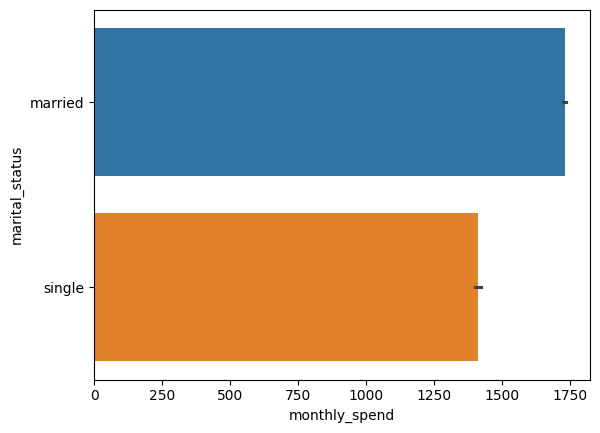

```python
#Display bar plot for visualizing relationship between this category and monthly spend
sns.barplot(data = a_data, x = 'monthly_spend', y = 'marital_status', hue = 'marital_status', orient = 'h')
plt.show()
```

```python
r_squared3 = model3.rsquared
r_squared3
```

```
np.float64(0.07917347435290178)
```

```python
pred = model3.predict()
rmse3 = np.sqrt(np.mean(np.square(pred - y)))
rmse3
```

```
np.float64(515.5887977293725)
```

```python
#model3 summary
model3.summary()
```

OLS Regression Results

| Dep. Variable: | monthly_spend | R-squared: | 0.079 |
| --- | --- | --- | --- |
| Model: | OLS | Adj. R-squared: | 0.079 |
| Method: | Least Squares | F-statistic: | 859.7 |
| Date: | Tue, 21 Oct 2025 | Prob (F-statistic): | 0.00 |
| Time: | 01:15:33 | Log-Likelihood: | -3.0657e+05 |
| No. Observations: | 40000 | AIC: | 6.131e+05 |
| Df Residuals: | 39995 | BIC: | 6.132e+05 |
| Df Model: | 4 |  |  |
| Covariance Type: | nonrobust |  |  |

|  | coef | std err | t | P>\|t\| | [0.025 | 0.975] |
| --- | --- | --- | --- | --- | --- | --- |
| Intercept | 1763.2456 | 5.306 | 332.315 | 0.000 | 1752.846 | 1773.645 |
| marital_status[T.single] | -319.2501 | 6.392 | -49.942 | 0.000 | -331.779 | -306.721 |
| employment_status[T.self-employed] | 82.8969 | 7.263 | 11.414 | 0.000 | 68.661 | 97.132 |
| employment_status[T.student] | -116.6698 | 7.298 | -15.985 | 0.000 | -130.975 | -102.365 |
| employment_status[T.unemployed] | -95.7910 | 7.290 | -13.140 | 0.000 | -110.080 | -81.502 |

| Omnibus: | 10073.830 | Durbin-Watson: | 1.990 |
| --- | --- | --- | --- |
| Prob(Omnibus): | 0.000 | Jarque-Bera (JB): | 44009.814 |
| Skew: | 1.175 | Prob(JB): | 0.00 |
| Kurtosis: | 7.570 | Cond. No. | 4.88 |

Notes:  
[1] Standard Errors assume that the covariance matrix of the errors is correctly specified.

```python
#submission 3
scoring_data = pd.read_csv('/content/drive/MyDrive/Colab Notebooks/Applied ML/scoring_data.csv')
scoring_data_X = scoring_data.loc[:,['marital_status', 'employment_status']]
pred = model3.predict(scoring_data_X)
```

```python
submission_file = pd.DataFrame({'customer_id': scoring_data.customer_id, 'monthly_spend': pred})
submission_file.to_csv('submission_file_3.csv',index = False)
```

# Submission 4

```python
#model4. Utilizing multiple regression to examine the effects of credit score and travel frequency
```

```python
train = a_data.sample(frac= 0.7 , random_state=617)
test = a_data.drop(train.index)
```

```python
reg = ols('monthly_spend~credit_score*travel_frequency', data = a_data)
model4 = reg.fit()
model4.params
```

|  | 0 |
| --- | --- |
| Intercept | 271.812599 |
| credit_score | 1.500487 |
| travel_frequency | 99.876147 |
| credit_score:travel_frequency | 0.028636 |

**dtype:** float64

```python
model4.summary()
```

OLS Regression Results

| Dep. Variable: | monthly_spend | R-squared: | 0.275 |
| --- | --- | --- | --- |
| Model: | OLS | Adj. R-squared: | 0.275 |
| Method: | Least Squares | F-statistic: | 5066. |
| Date: | Wed, 22 Oct 2025 | Prob (F-statistic): | 0.00 |
| Time: | 00:34:04 | Log-Likelihood: | -3.0178e+05 |
| No. Observations: | 40000 | AIC: | 6.036e+05 |
| Df Residuals: | 39996 | BIC: | 6.036e+05 |
| Df Model: | 3 |  |  |
| Covariance Type: | nonrobust |  |  |

|  | coef | std err | t | P>\|t\| | [0.025 | 0.975] |
| --- | --- | --- | --- | --- | --- | --- |
| Intercept | 271.8126 | 51.816 | 5.246 | 0.000 | 170.253 | 373.373 |
| credit_score | 1.5005 | 0.074 | 20.308 | 0.000 | 1.356 | 1.645 |
| travel_frequency | 99.8761 | 14.284 | 6.992 | 0.000 | 71.880 | 127.872 |
| credit_score:travel_frequency | 0.0286 | 0.020 | 1.405 | 0.160 | -0.011 | 0.069 |

| Omnibus: | 3118.287 | Durbin-Watson: | 2.000 |
| --- | --- | --- | --- |
| Prob(Omnibus): | 0.000 | Jarque-Bera (JB): | 7125.273 |
| Skew: | 0.494 | Prob(JB): | 0.00 |
| Kurtosis: | 4.817 | Cond. No. | 6.08e+04 |

Notes:  
[1] Standard Errors assume that the covariance matrix of the errors is correctly specified.  
[2] The condition number is large, 6.08e+04. This might indicate that there are  
strong multicollinearity or other numerical problems.

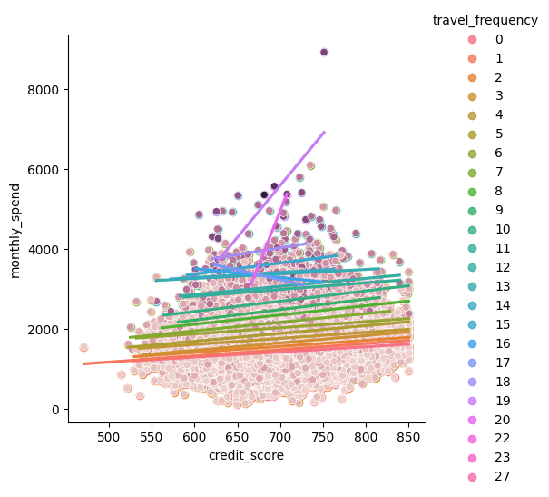

```python
#Plotting charts to visualize the results

sns.lmplot(data = train, x = 'credit_score', y = 'monthly_spend', hue = 'travel_frequency', ci = None )

sns.scatterplot(data = train , x = 'credit_score', y = 'monthly_spend', hue = 'travel_frequency', legend = False)
plt.show()
```

```python
#prediction

r_squared4 = model4.rsquared
r_squared4
```

```
np.float64(0.2753562894725129)
```

```python
pred = model4.predict()
rmse4 = np.sqrt(np.mean(np.square(pred - y)))
rmse4
```

```
np.float64(457.379637298119)
```

```python
#submission 4 files
scoring_data = pd.read_csv('/content/drive/MyDrive/Colab Notebooks/Applied ML/scoring_data.csv')
scoring_data_x = scoring_data.loc[:,['credit_score', 'travel_frequency']]
pred = model4.predict(scoring_data_x)
```

```python
submission_file = pd.DataFrame({'customer_id': scoring_data.customer_id, 'monthly_spend': pred})
submission_file.to_csv('submission_file_4.csv',index = False)
```

# Submission 5

```python
import pandas as pd
import numpy as np

df = pd.read_csv('/content/drive/MyDrive/Colab Notebooks/Applied ML/analysis_data.csv')
df.head()
```

```python
#Using Multiple regression with most of the predictors. Using OLS

reg = ols('monthly_spend~age+gender+marital_status+education_level+region+employment_status+owns_home+has_auto_loan+annual_income+credit_score+credit_limit+tenure+card_type+num_transactions+avg_transaction_value+online_shopping_freq+reward_points_balance+utility_payment_count+num_children+travel_frequency+num_credit_cards',
          data = a_data)
model5 = reg.fit()
model5.params
```

|  | 0 |
| --- | --- |
| Intercept | 279.211377 |
| gender[T.male] | -51.926701 |
| marital_status[T.single] | -218.866590 |
| education_level[T.graduate] | 44.298161 |
| education_level[T.high school] | -54.814335 |
| region[T.northeast] | 16.724207 |
| region[T.south] | -19.923837 |
| region[T.west] | 41.392423 |
| employment_status[T.self-employed] | 73.863025 |
| employment_status[T.student] | -53.620764 |
| employment_status[T.unemployed] | -99.695487 |
| card_type[T.platinum] | 145.468034 |
| card_type[T.standard] | -156.415086 |
| age | -0.007039 |
| owns_home | 96.794973 |
| has_auto_loan | 55.411107 |
| annual_income | 0.000568 |
| credit_score | 0.299384 |
| credit_limit | 0.003006 |
| tenure | 15.001286 |
| num_transactions | 18.357754 |
| avg_transaction_value | 5.738447 |
| online_shopping_freq | 4.110733 |
| reward_points_balance | 0.015284 |
| utility_payment_count | 20.064693 |
| num_children | 148.780635 |
| travel_frequency | 25.479940 |
| num_credit_cards | 21.524222 |

**dtype:** float64

```python
model5.summary()
```

OLS Regression Results

| Dep. Variable: | monthly_spend | R-squared: | 0.771 |
| --- | --- | --- | --- |
| Model: | OLS | Adj. R-squared: | 0.771 |
| Method: | Least Squares | F-statistic: | 4513. |
| Date: | Thu, 23 Oct 2025 | Prob (F-statistic): | 0.00 |
| Time: | 13:48:44 | Log-Likelihood: | -2.5172e+05 |
| No. Observations: | 36118 | AIC: | 5.035e+05 |
| Df Residuals: | 36090 | BIC: | 5.037e+05 |
| Df Model: | 27 |  |  |
| Covariance Type: | nonrobust |  |  |

|  | coef | std err | t | P>\|t\| | [0.025 | 0.975] |
| --- | --- | --- | --- | --- | --- | --- |
| Intercept | 279.2114 | 64.094 | 4.356 | 0.000 | 153.586 | 404.837 |
| gender[T.male] | -51.9267 | 2.710 | -19.159 | 0.000 | -57.239 | -46.614 |
| marital_status[T.single] | -218.8666 | 4.528 | -48.340 | 0.000 | -227.741 | -209.992 |
| education_level[T.graduate] | 44.2982 | 3.503 | 12.646 | 0.000 | 37.432 | 51.164 |
| education_level[T.high school] | -54.8143 | 3.482 | -15.744 | 0.000 | -61.638 | -47.990 |
| region[T.northeast] | 16.7242 | 3.822 | 4.376 | 0.000 | 9.233 | 24.215 |
| region[T.south] | -19.9238 | 3.829 | -5.203 | 0.000 | -27.429 | -12.419 |
| region[T.west] | 41.3924 | 3.838 | 10.785 | 0.000 | 33.870 | 48.915 |
| employment_status[T.self-employed] | 73.8630 | 3.815 | 19.362 | 0.000 | 66.386 | 81.340 |
| employment_status[T.student] | -53.6208 | 3.884 | -13.806 | 0.000 | -61.233 | -46.008 |
| employment_status[T.unemployed] | -99.6955 | 3.835 | -25.994 | 0.000 | -107.213 | -92.178 |
| card_type[T.platinum] | 145.4680 | 6.350 | 22.908 | 0.000 | 133.022 | 157.914 |
| card_type[T.standard] | -156.4151 | 4.405 | -35.509 | 0.000 | -165.049 | -147.781 |
| age | -0.0070 | 0.097 | -0.073 | 0.942 | -0.196 | 0.182 |
| owns_home | 96.7950 | 2.710 | 35.715 | 0.000 | 91.483 | 102.107 |
| has_auto_loan | 55.4111 | 2.710 | 20.446 | 0.000 | 50.099 | 60.723 |
| annual_income | 0.0006 | 0.000 | 1.177 | 0.239 | -0.000 | 0.002 |
| credit_score | 0.2994 | 0.043 | 6.942 | 0.000 | 0.215 | 0.384 |
| credit_limit | 0.0030 | 0.001 | 4.552 | 0.000 | 0.002 | 0.004 |
| tenure | 15.0013 | 0.234 | 64.048 | 0.000 | 14.542 | 15.460 |
| num_transactions | 18.3578 | 0.404 | 45.411 | 0.000 | 17.565 | 19.150 |
| avg_transaction_value | 5.7384 | 0.068 | 84.795 | 0.000 | 5.606 | 5.871 |
| online_shopping_freq | 4.1107 | 0.475 | 8.656 | 0.000 | 3.180 | 5.042 |
| reward_points_balance | 0.0153 | 0.005 | 3.385 | 0.001 | 0.006 | 0.024 |
| utility_payment_count | 20.0647 | 0.750 | 26.761 | 0.000 | 18.595 | 21.534 |
| num_children | 148.7806 | 1.255 | 118.568 | 0.000 | 146.321 | 151.240 |
| travel_frequency | 25.4799 | 0.802 | 31.786 | 0.000 | 23.909 | 27.051 |
| num_credit_cards | 21.5242 | 6.838 | 3.148 | 0.002 | 8.122 | 34.927 |

| Omnibus: | 678.211 | Durbin-Watson: | 2.005 |
| --- | --- | --- | --- |
| Prob(Omnibus): | 0.000 | Jarque-Bera (JB): | 1336.897 |
| Skew: | 0.094 | Prob(JB): | 4.97e-291 |
| Kurtosis: | 3.923 | Cond. No. | 3.93e+06 |

Notes:  
[1] Standard Errors assume that the covariance matrix of the errors is correctly specified.  
[2] The condition number is large, 3.93e+06. This might indicate that there are  
strong multicollinearity or other numerical problems.

```python
rsquared5 = model5.rsquared
rsquared5
```

[output not shown]

```python
pred = model5.predict()
rmse5 = np.sqrt(np.mean(np.square(model5.fittedvalues - y.loc[model5.fittedvalues.index])))
rmse5
```

[output not shown]

```python
#submission 5
#scrap code. Put back if not working. ['','','','age','gender', 'marital_status', 'education_level','region', 'employment_status', 'owns_home', 'annual_income', 'credit_score', 'credit_limit', 'card_type', 'num_transactions', 'avg_transaction_value', 'online_shopping_freq', 'reward_points_balance', 'travel_frequency', 'num_credit_cards']]
scoring_data = pd.read_csv('/content/drive/MyDrive/Colab Notebooks/Applied ML/scoring_data.csv')
scoring_data_x = scoring_data.values[:,:-1]
print(scoring_data_x)
scoring_data.head()
pred = model5.predict(scoring_data_x)
```

```
[[20451981 68 'female' ... 3 5.0 2]
 [23251656 37 'male' ... 7 7.0 3]
 [64082260 65 'female' ... 5 1.0 1]
 ...
 [17932616 62 'male' ... 3 1.0 1]
 [86326117 23 'male' ... 3 4.0 0]
 [64151997 41 'female' ... 2 4.0 2]]
```

```python
submission_file = pd.DataFrame({'customer_id': scoring_data.customer_id, 'monthly_spend': pred})
submission_file.to_csv('submission_file_5.csv',index = False)
```